# Report

Koustubh Dwivedy, Pratik Acharya

December 16, 2016

# Company Report AMZN

## Price Returns

The dollar change based solely on the closing price of a security is called capital gains and the percentage price in the closing price of a security is its price return. The price return is measured over some investment horizon (e.g., 1 day, 1 month, 1 year, etc.). The length of the period depends on the application, but the return calculations should be consistent such that cumulating all the 1-day returns in a given year should equal the annual return.

## Total Returns

The return to investors from holding shares of stock are not limited to changes in the price of the security. For companies that pay dividends, the shareholders holding shares prior to the ex-dividend date receive cash payments that they are able to reinvest. In fact, automatically reinvesting dividends may be an option for some securities. Therefore, the total return a shareholder can receive from a stock that pays dividends includes both the change in the price of the shares she owns as well as any income generated from the dividends and the reinvestment of those dividends on the ex-date. This is known as the holding period return or total return.

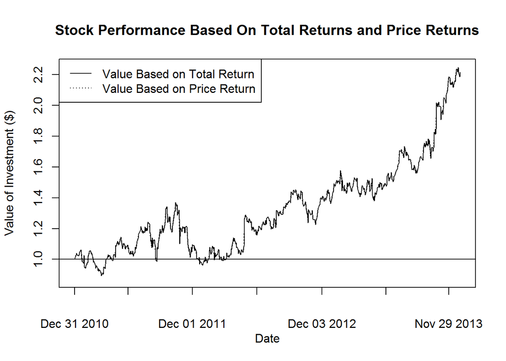

## Airthmatic Cumulative Returns

```
##            NetCum
## 2013-12-31 1.2155
```

This means that an investment made in AMZN stock on 2010-12-31 would have returned 121.550005000001% by the end of 2013-12-31.

## Logarithmic Cumulative Returns

```
## [1] 0.7954781
```

## Logarithmic Total Returns

[Lograthmic Return](https://en.wikipedia.org/wiki/Rate_of_return#Logarithmic_or_continuously_compounded_return)

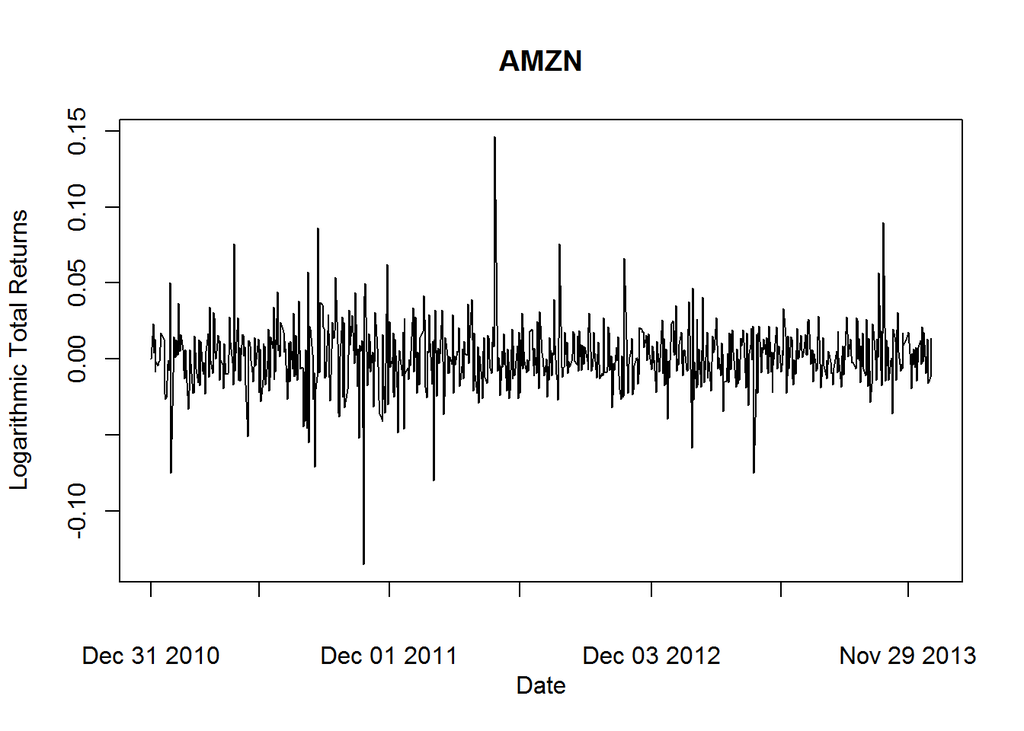

## Weekly Returns

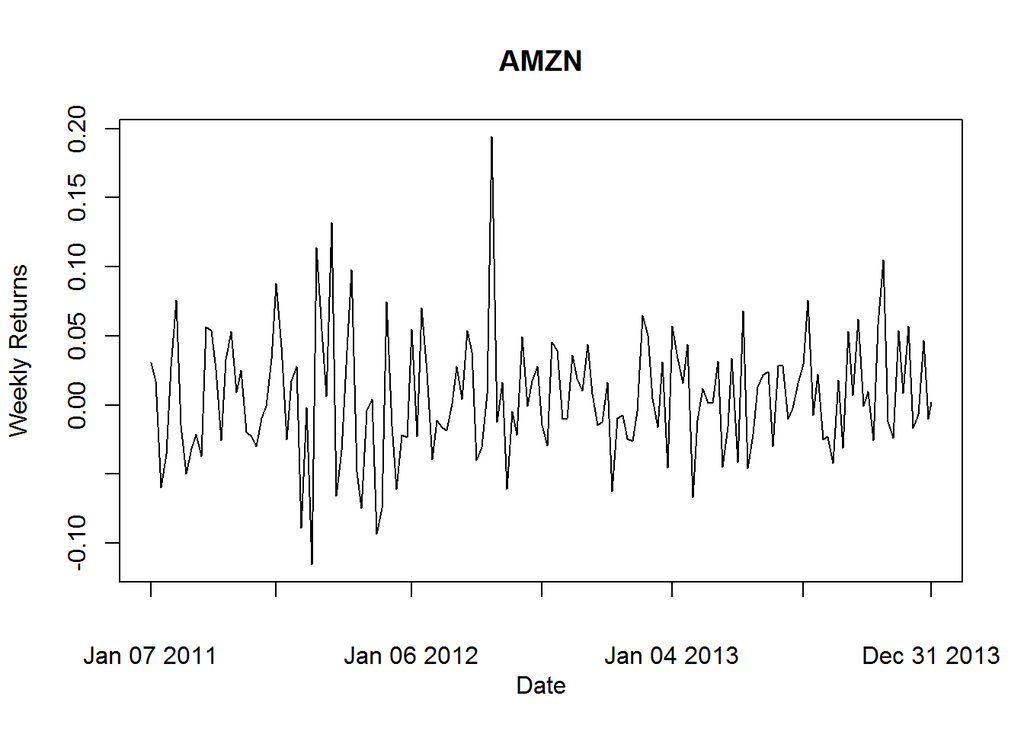

## Monthly Returns

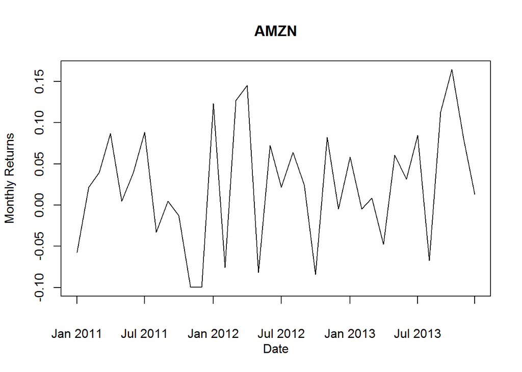

## Drawdowns

```
##         From     Trough         To   Depth Length To Trough Recovery
## 3 2011-01-19 2011-03-17 2011-04-27 -0.1583     69        41       28
## 2 2011-07-29 2011-08-22 2011-09-15 -0.2071     34        17       17
## 1 2011-10-17 2011-12-30 2012-08-29 -0.2984    220        53      167
## 4 2012-09-20 2012-11-15 2013-01-07 -0.1570     73        39       34
## 5 2013-01-28 2013-05-01 2013-07-03 -0.1259    110        66       44
```